# DS 2003 Midterm Report

Exploring NBA 2021-2022 Stats

Kevin Ma, Eva Massarelli, Hank Dickerson

3-17-2023

# Executive Summary

This report utilizes NBA data to create clear and informative plots that demonstrate differences in NBA seasons and positions. This report is geared towards readers looking to understand more about how different players perform in the playoffs vs during the regular season and which positions in the NBA let players have the most playtime. Stakeholders interested in this may be recruiters, coaches, or fantasy league players.

# Report Dependencies

```r
library(tidyverse)
library(ggplot2)
library(reshape2)
library(skimr)
library(pollster)
library(kableExtra)
```

# Data Set

Our data, [“2021-2022 NBA Player Stats,”](https://www.kaggle.com/datasets/vivovinco/nba-player-stats) was found on Kaggle and is owned by Vivo Vinco. We accessed the data through mid-February to mid-March.

Import data

```r
playoffs <- read.csv('2021-2022 NBA Player Stats - Playoffs.csv')
playoffs %>%
  kbl() %>%
  kable_styling("hover") %>%
  scroll_box(width = "800px", height = "200px")
```

| Rk | Player | Pos | Age | Tm | G | GS | MP | FG | FGA | FG. | X3P | X3PA | X3P. | X2P | X2PA | X2P. | eFG. | FT | FTA | FT. | ORB | DRB | TRB | AST | STL | BLK | TOV | PF | PTS |
| --- | --- | --- | --- | --- | --- | --- | --- | --- | --- | --- | --- | --- | --- | --- | --- | --- | --- | --- | --- | --- | --- | --- | --- | --- | --- | --- | --- | --- | --- |
| 1 | Precious Achiuwa | C | 22 | TOR | 6 | 1 | 27.8 | 4.2 | 8.7 | 0.481 | 0.8 | 2.7 | 0.313 | 3.3 | 6.0 | 0.556 | 0.529 | 1.0 | 1.7 | 0.600 | 1.3 | 3.5 | 4.8 | 1.0 | 0.2 | 0.8 | 1.5 | 2.3 | 10.2 |
| 2 | Steven Adams | C | 28 | MEM | 7 | 5 | 16.3 | 1.3 | 3.0 | 0.429 | 0.0 | 0.0 | 0.000 | 1.3 | 3.0 | 0.429 | 0.429 | 0.9 | 1.6 | 0.545 | 2.1 | 4.3 | 6.4 | 2.1 | 0.1 | 0.1 | 0.6 | 1.7 | 3.4 |
| 3 | Bam Adebayo | C | 24 | MIA | 18 | 18 | 34.1 | 5.8 | 9.7 | 0.594 | 0.0 | 0.1 | 0.000 | 5.8 | 9.7 | 0.598 | 0.594 | 3.2 | 4.2 | 0.763 | 2.1 | 5.9 | 8.0 | 2.7 | 1.0 | 0.7 | 2.1 | 3.1 | 14.8 |
| 4 | Nickeil Alexander-Walker | SG | 23 | UTA | 1 | 0 | 5.0 | 2.0 | 2.0 | 1.000 | 0.0 | 0.0 | 0.000 | 2.0 | 2.0 | 1.000 | 1.000 | 1.0 | 1.0 | 1.000 | 0.0 | 1.0 | 1.0 | 1.0 | 1.0 | 0.0 | 0.0 | 0.0 | 5.0 |
| 5 | Grayson Allen | SG | 26 | MIL | 12 | 5 | 25.4 | 3.1 | 6.8 | 0.451 | 1.6 | 4.0 | 0.396 | 1.5 | 2.8 | 0.529 | 0.567 | 0.6 | 0.9 | 0.636 | 0.4 | 2.5 | 2.9 | 1.3 | 0.7 | 0.3 | 0.8 | 1.8 | 8.3 |
| 6 | Jose Alvarado | PG | 23 | NOP | 6 | 0 | 19.5 | 2.7 | 5.5 | 0.485 | 1.0 | 2.7 | 0.375 | 1.7 | 2.8 | 0.588 | 0.576 | 1.7 | 2.2 | 0.769 | 0.3 | 1.0 | 1.3 | 1.5 | 1.2 | 0.2 | 1.2 | 3.0 | 8.0 |
| 7 | Kyle Anderson | PF | 28 | MEM | 12 | 1 | 18.4 | 2.4 | 4.3 | 0.569 | 0.3 | 1.0 | 0.250 | 2.2 | 3.3 | 0.667 | 0.598 | 0.9 | 1.5 | 0.611 | 0.8 | 3.5 | 4.3 | 1.8 | 0.9 | 0.6 | 0.8 | 1.8 | 6.0 |
| 8 | Giannis Antetokounmpo | PF | 27 | MIL | 12 | 12 | 37.3 | 11.7 | 23.8 | 0.491 | 0.8 | 3.4 | 0.220 | 10.9 | 20.3 | 0.537 | 0.507 | 7.6 | 11.2 | 0.679 | 2.2 | 12.0 | 14.2 | 6.8 | 0.7 | 1.3 | 4.5 | 3.6 | 31.7 |
| 9 | Thanasis Antetokounmpo | SF | 29 | MIL | 8 | 0 | 2.5 | 0.3 | 0.4 | 0.667 | 0.0 | 0.0 | 0.000 | 0.3 | 0.4 | 0.667 | 0.667 | 0.1 | 0.4 | 0.333 | 0.1 | 0.4 | 0.5 | 0.1 | 0.1 | 0.0 | 0.0 | 0.5 | 0.6 |
| 10 | OG Anunoby | SF | 24 | TOR | 6 | 6 | 36.2 | 6.5 | 13.7 | 0.476 | 2.3 | 6.8 | 0.341 | 4.2 | 6.8 | 0.610 | 0.561 | 2.0 | 2.7 | 0.750 | 1.2 | 2.8 | 4.0 | 2.5 | 1.0 | 0.2 | 1.7 | 3.0 | 17.3 |
| 11 | Deandre Ayton | C | 23 | PHO | 13 | 13 | 30.5 | 8.1 | 12.6 | 0.640 | 0.2 | 0.3 | 0.500 | 7.9 | 12.3 | 0.644 | 0.646 | 1.6 | 2.5 | 0.636 | 2.5 | 6.4 | 8.9 | 1.7 | 0.4 | 0.8 | 1.5 | 2.6 | 17.9 |
| 12 | Desmond Bane | SF | 23 | MEM | 12 | 12 | 35.7 | 6.3 | 13.3 | 0.478 | 3.6 | 7.3 | 0.489 | 2.8 | 5.9 | 0.465 | 0.613 | 2.5 | 2.9 | 0.857 | 0.4 | 3.3 | 3.8 | 2.2 | 0.9 | 0.8 | 1.3 | 1.9 | 18.8 |
| 13 | Dalano Banton | PG | 22 | TOR | 4 | 0 | 2.0 | 0.5 | 0.5 | 1.000 | 0.0 | 0.0 | 0.000 | 0.5 | 0.5 | 1.000 | 1.000 | 0.8 | 1.5 | 0.500 | 0.5 | 0.0 | 0.5 | 0.3 | 0.3 | 0.0 | 0.3 | 0.0 | 1.8 |
| 14 | Scottie Barnes | PF | 20 | TOR | 4 | 3 | 33.3 | 4.5 | 10.5 | 0.429 | 0.5 | 3.0 | 0.167 | 4.0 | 7.5 | 0.533 | 0.452 | 3.3 | 4.0 | 0.813 | 1.8 | 7.3 | 9.0 | 4.3 | 1.0 | 0.3 | 1.3 | 3.0 | 12.8 |
| 15 | Will Barton | SG | 31 | DEN | 5 | 5 | 34.4 | 5.4 | 13.2 | 0.409 | 2.2 | 5.6 | 0.393 | 3.2 | 7.6 | 0.421 | 0.492 | 0.8 | 1.2 | 0.667 | 1.0 | 4.6 | 5.6 | 2.8 | 0.8 | 0.2 | 2.0 | 2.2 | 13.8 |
| 16 | Charles Bassey | PF | 21 | PHI | 3 | 0 | 4.0 | 0.3 | 0.7 | 0.500 | 0.0 | 0.0 | 0.000 | 0.3 | 0.7 | 0.500 | 0.500 | 0.0 | 0.3 | 0.000 | 0.3 | 1.3 | 1.7 | 0.3 | 0.0 | 0.3 | 0.0 | 0.3 | 0.7 |
| 17 | Malik Beasley | SG | 25 | MIN | 6 | 0 | 19.8 | 3.2 | 7.3 | 0.432 | 1.3 | 4.2 | 0.320 | 1.8 | 3.2 | 0.579 | 0.523 | 0.8 | 1.0 | 0.833 | 0.3 | 3.0 | 3.3 | 0.7 | 0.3 | 0.2 | 1.2 | 1.5 | 8.5 |
| 18 | D?vis Bert?ns | PF | 29 | DAL | 18 | 0 | 10.7 | 1.2 | 3.1 | 0.400 | 1.1 | 2.8 | 0.373 | 0.2 | 0.2 | 0.750 | 0.573 | 0.6 | 0.7 | 0.833 | 0.2 | 1.2 | 1.4 | 0.3 | 0.4 | 0.1 | 0.2 | 1.4 | 4.1 |
| 19 | Patrick Beverley | PG | 33 | MIN | 6 | 6 | 32.3 | 3.5 | 8.2 | 0.429 | 1.5 | 4.3 | 0.346 | 2.0 | 3.8 | 0.522 | 0.520 | 2.5 | 3.7 | 0.682 | 0.7 | 2.5 | 3.2 | 4.8 | 1.2 | 1.2 | 2.0 | 4.7 | 11.0 |
| 20 | Khem Birch | C | 29 | TOR | 6 | 4 | 10.5 | 1.3 | 2.7 | 0.500 | 0.3 | 0.7 | 0.500 | 1.0 | 2.0 | 0.500 | 0.563 | 0.0 | 0.0 | 0.000 | 0.7 | 0.8 | 1.5 | 0.5 | 0.2 | 0.2 | 0.5 | 2.2 | 3.0 |
| 21 | Bismack Biyombo | C | 29 | PHO | 9 | 0 | 9.6 | 1.2 | 1.9 | 0.647 | 0.0 | 0.0 | 0.000 | 1.2 | 1.9 | 0.647 | 0.647 | 0.3 | 0.7 | 0.500 | 0.9 | 1.2 | 2.1 | 0.6 | 0.1 | 0.2 | 0.7 | 1.4 | 2.8 |
| 22 | Nemanja Bjelica | C | 33 | GSW | 15 | 0 | 10.0 | 1.2 | 2.3 | 0.529 | 0.2 | 0.5 | 0.375 | 1.0 | 1.7 | 0.577 | 0.574 | 0.3 | 0.5 | 0.571 | 0.4 | 1.7 | 2.1 | 1.1 | 0.3 | 0.1 | 0.5 | 1.4 | 2.9 |
| 23 | Bogdan Bogdanovi? | SG | 29 | ATL | 4 | 0 | 26.8 | 5.0 | 12.3 | 0.408 | 2.3 | 6.5 | 0.346 | 2.8 | 5.8 | 0.478 | 0.500 | 2.0 | 2.5 | 0.800 | 1.0 | 3.8 | 4.8 | 3.0 | 0.3 | 0.3 | 1.0 | 3.0 | 14.3 |
| 24 | Bojan Bogdanovi? | PF | 32 | UTA | 6 | 6 | 35.7 | 6.5 | 13.5 | 0.481 | 1.8 | 5.5 | 0.333 | 4.7 | 8.0 | 0.583 | 0.549 | 3.2 | 4.0 | 0.792 | 0.5 | 3.7 | 4.2 | 1.7 | 0.3 | 0.0 | 2.0 | 4.0 | 18.0 |
| 25 | Isaac Bonga | SF | 22 | TOR | 1 | 0 | 3.0 | 0.0 | 0.0 | 0.000 | 0.0 | 0.0 | 0.000 | 0.0 | 0.0 | 0.000 | 0.000 | 2.0 | 2.0 | 1.000 | 0.0 | 1.0 | 1.0 | 0.0 | 0.0 | 0.0 | 0.0 | 1.0 | 2.0 |
| 26 | Devin Booker | SG | 25 | PHO | 10 | 10 | 36.6 | 7.9 | 17.5 | 0.451 | 2.8 | 6.5 | 0.431 | 5.1 | 11.0 | 0.464 | 0.531 | 4.7 | 5.3 | 0.887 | 1.0 | 3.8 | 4.8 | 4.4 | 0.5 | 0.4 | 3.2 | 2.5 | 23.3 |
| 27 | Chris Boucher | PF | 29 | TOR | 6 | 0 | 21.7 | 4.3 | 7.0 | 0.619 | 1.0 | 2.5 | 0.400 | 3.3 | 4.5 | 0.741 | 0.690 | 1.5 | 1.7 | 0.900 | 2.0 | 3.8 | 5.8 | 0.2 | 0.2 | 1.2 | 0.3 | 2.2 | 11.2 |
| 28 | Tony Bradley | C | 24 | CHI | 2 | 0 | 4.0 | 2.5 | 2.5 | 1.000 | 0.0 | 0.0 | 0.000 | 2.5 | 2.5 | 1.000 | 1.000 | 0.0 | 0.0 | 0.000 | 0.0 | 2.0 | 2.0 | 0.5 | 0.0 | 0.0 | 0.0 | 0.0 | 5.0 |
| 29 | Mikal Bridges | SF | 25 | PHO | 13 | 13 | 38.5 | 5.1 | 10.6 | 0.478 | 1.0 | 2.5 | 0.394 | 4.1 | 8.1 | 0.505 | 0.525 | 2.2 | 2.3 | 0.933 | 0.9 | 3.8 | 4.7 | 2.8 | 1.1 | 1.0 | 0.8 | 2.4 | 13.3 |
| 30 | Armoni Brooks | PG | 23 | TOR | 4 | 0 | 2.0 | 0.0 | 1.0 | 0.000 | 0.0 | 1.0 | 0.000 | 0.0 | 0.0 | 0.000 | 0.000 | 0.0 | 0.0 | 0.000 | 0.0 | 0.5 | 0.5 | 0.0 | 0.0 | 0.0 | 0.0 | 0.0 | 0.0 |

[output cut: 187 more lines]

```r
regular <- read.csv('2021-2022 NBA Player Stats - Regular.csv')
regular %>%
  kbl() %>%
  kable_styling("hover") %>%
  scroll_box(width = "800px", height = "200px")
```

| Rk | Player | Pos | Age | Tm | G | GS | MP | FG | FGA | FG. | X3P | X3PA | X3P. | X2P | X2PA | X2P. | eFG. | FT | FTA | FT. | ORB | DRB | TRB | AST | STL | BLK | TOV | PF | PTS |
| --- | --- | --- | --- | --- | --- | --- | --- | --- | --- | --- | --- | --- | --- | --- | --- | --- | --- | --- | --- | --- | --- | --- | --- | --- | --- | --- | --- | --- | --- |
| 1 | Precious Achiuwa | C | 22 | TOR | 73 | 28 | 23.6 | 3.6 | 8.3 | 0.439 | 0.8 | 2.1 | 0.359 | 2.9 | 6.1 | 0.468 | 0.486 | 1.1 | 1.8 | 0.595 | 2.0 | 4.5 | 6.5 | 1.1 | 0.5 | 0.6 | 1.2 | 2.1 | 9.1 |
| 2 | Steven Adams | C | 28 | MEM | 76 | 75 | 26.3 | 2.8 | 5.1 | 0.547 | 0.0 | 0.0 | 0.000 | 2.8 | 5.0 | 0.548 | 0.547 | 1.4 | 2.6 | 0.543 | 4.6 | 5.4 | 10.0 | 3.4 | 0.9 | 0.8 | 1.5 | 2.0 | 6.9 |
| 3 | Bam Adebayo | C | 24 | MIA | 56 | 56 | 32.6 | 7.3 | 13.0 | 0.557 | 0.0 | 0.1 | 0.000 | 7.3 | 12.9 | 0.562 | 0.557 | 4.6 | 6.1 | 0.753 | 2.4 | 7.6 | 10.1 | 3.4 | 1.4 | 0.8 | 2.6 | 3.1 | 19.1 |
| 4 | Santi Aldama | PF | 21 | MEM | 32 | 0 | 11.3 | 1.7 | 4.1 | 0.402 | 0.2 | 1.5 | 0.125 | 1.5 | 2.6 | 0.560 | 0.424 | 0.6 | 1.0 | 0.625 | 1.0 | 1.7 | 2.7 | 0.7 | 0.2 | 0.3 | 0.5 | 1.1 | 4.1 |
| 5 | LaMarcus Aldridge | C | 36 | BRK | 47 | 12 | 22.3 | 5.4 | 9.7 | 0.550 | 0.3 | 1.0 | 0.304 | 5.1 | 8.8 | 0.578 | 0.566 | 1.9 | 2.2 | 0.873 | 1.6 | 3.9 | 5.5 | 0.9 | 0.3 | 1.0 | 0.9 | 1.7 | 12.9 |
| 6 | Nickeil Alexander-Walker | SG | 23 | TOT | 65 | 21 | 22.6 | 3.9 | 10.5 | 0.372 | 1.6 | 5.2 | 0.311 | 2.3 | 5.3 | 0.433 | 0.449 | 1.2 | 1.7 | 0.743 | 0.6 | 2.3 | 2.9 | 2.4 | 0.7 | 0.4 | 1.4 | 1.6 | 10.6 |
| 6 | Nickeil Alexander-Walker | SG | 23 | NOP | 50 | 19 | 26.3 | 4.7 | 12.6 | 0.375 | 1.9 | 6.1 | 0.311 | 2.8 | 6.5 | 0.434 | 0.450 | 1.4 | 1.9 | 0.722 | 0.7 | 2.6 | 3.3 | 2.8 | 0.8 | 0.4 | 1.7 | 1.8 | 12.8 |
| 6 | Nickeil Alexander-Walker | SG | 23 | UTA | 15 | 2 | 9.9 | 1.1 | 3.2 | 0.333 | 0.7 | 2.2 | 0.303 | 0.4 | 1.0 | 0.400 | 0.438 | 0.7 | 0.8 | 0.917 | 0.1 | 1.5 | 1.5 | 1.1 | 0.3 | 0.3 | 0.5 | 1.0 | 3.5 |
| 7 | Grayson Allen | SG | 26 | MIL | 66 | 61 | 27.3 | 3.9 | 8.6 | 0.448 | 2.4 | 5.9 | 0.409 | 1.5 | 2.7 | 0.533 | 0.588 | 1.0 | 1.1 | 0.865 | 0.5 | 2.9 | 3.4 | 1.5 | 0.7 | 0.3 | 0.7 | 1.5 | 11.1 |
| 8 | Jarrett Allen | C | 23 | CLE | 56 | 56 | 32.3 | 6.6 | 9.7 | 0.677 | 0.0 | 0.2 | 0.100 | 6.6 | 9.6 | 0.688 | 0.678 | 2.9 | 4.2 | 0.708 | 3.4 | 7.3 | 10.8 | 1.6 | 0.8 | 1.3 | 1.7 | 1.7 | 16.1 |
| 9 | Jose Alvarado | PG | 23 | NOP | 54 | 1 | 15.4 | 2.4 | 5.4 | 0.446 | 0.6 | 2.0 | 0.291 | 1.8 | 3.4 | 0.538 | 0.500 | 0.7 | 1.0 | 0.679 | 0.5 | 1.4 | 1.9 | 2.8 | 1.3 | 0.1 | 0.7 | 1.4 | 6.1 |
| 10 | Justin Anderson | SF | 28 | TOT | 16 | 6 | 19.8 | 2.3 | 5.9 | 0.379 | 0.9 | 3.7 | 0.254 | 1.3 | 2.3 | 0.583 | 0.458 | 0.9 | 1.2 | 0.789 | 0.3 | 2.6 | 2.9 | 2.1 | 0.5 | 0.4 | 0.5 | 1.4 | 6.4 |
| 10 | Justin Anderson | SF | 28 | CLE | 3 | 0 | 15.7 | 1.3 | 2.7 | 0.500 | 0.7 | 2.0 | 0.333 | 0.7 | 0.7 | 1.000 | 0.625 | 1.0 | 1.3 | 0.750 | 0.0 | 2.0 | 2.0 | 2.0 | 0.3 | 0.0 | 0.7 | 1.3 | 4.3 |
| 10 | Justin Anderson | SF | 28 | IND | 13 | 6 | 20.7 | 2.5 | 6.7 | 0.368 | 1.0 | 4.1 | 0.245 | 1.5 | 2.6 | 0.559 | 0.443 | 0.9 | 1.2 | 0.800 | 0.3 | 2.8 | 3.1 | 2.1 | 0.5 | 0.5 | 0.5 | 1.4 | 6.8 |
| 11 | Kyle Anderson | PF | 28 | MEM | 69 | 11 | 21.5 | 3.0 | 6.8 | 0.446 | 0.5 | 1.6 | 0.330 | 2.5 | 5.2 | 0.481 | 0.484 | 1.0 | 1.5 | 0.638 | 1.0 | 4.3 | 5.3 | 2.7 | 1.1 | 0.7 | 1.0 | 1.6 | 7.6 |
| 12 | Giannis Antetokounmpo | PF | 27 | MIL | 67 | 67 | 32.9 | 10.3 | 18.6 | 0.553 | 1.1 | 3.6 | 0.293 | 9.2 | 15.0 | 0.616 | 0.582 | 8.3 | 11.4 | 0.722 | 2.0 | 9.6 | 11.6 | 5.8 | 1.1 | 1.4 | 3.3 | 3.2 | 29.9 |
| 13 | Thanasis Antetokounmpo | SF | 29 | MIL | 48 | 6 | 9.9 | 1.5 | 2.7 | 0.547 | 0.0 | 0.3 | 0.143 | 1.4 | 2.4 | 0.596 | 0.555 | 0.6 | 1.0 | 0.630 | 0.8 | 1.3 | 2.1 | 0.5 | 0.3 | 0.3 | 0.5 | 1.4 | 3.6 |
| 14 | Carmelo Anthony | PF | 37 | LAL | 69 | 3 | 26.0 | 4.6 | 10.5 | 0.441 | 2.2 | 5.8 | 0.375 | 2.5 | 4.7 | 0.521 | 0.544 | 1.9 | 2.3 | 0.830 | 0.9 | 3.3 | 4.2 | 1.0 | 0.7 | 0.8 | 0.9 | 2.4 | 13.3 |
| 15 | Cole Anthony | PG | 21 | ORL | 65 | 65 | 31.7 | 5.5 | 14.0 | 0.391 | 2.0 | 6.0 | 0.338 | 3.5 | 8.0 | 0.432 | 0.464 | 3.3 | 3.9 | 0.854 | 0.5 | 4.9 | 5.4 | 5.7 | 0.7 | 0.3 | 2.6 | 2.6 | 16.3 |
| 16 | OG Anunoby | SF | 24 | TOR | 48 | 48 | 36.0 | 6.4 | 14.5 | 0.443 | 2.4 | 6.6 | 0.363 | 4.0 | 7.9 | 0.511 | 0.526 | 1.9 | 2.5 | 0.754 | 1.5 | 4.0 | 5.5 | 2.6 | 1.5 | 0.5 | 1.7 | 2.7 | 17.1 |
| 17 | Ryan Arcidiacono | PG | 27 | NYK | 10 | 0 | 7.6 | 0.6 | 1.2 | 0.500 | 0.4 | 0.9 | 0.444 | 0.2 | 0.3 | 0.667 | 0.667 | 0.0 | 0.0 | 0.000 | 0.0 | 0.8 | 0.8 | 0.4 | 0.1 | 0.0 | 0.3 | 0.5 | 1.6 |
| 18 | Trevor Ariza | SF | 36 | LAL | 24 | 11 | 19.3 | 1.4 | 4.1 | 0.333 | 0.8 | 3.1 | 0.270 | 0.5 | 1.0 | 0.520 | 0.434 | 0.4 | 0.8 | 0.556 | 0.4 | 3.0 | 3.4 | 1.1 | 0.5 | 0.3 | 0.5 | 0.8 | 4.0 |
| 19 | D.J. Augustin | PG | 34 | TOT | 55 | 2 | 16.1 | 1.7 | 4.0 | 0.423 | 1.2 | 3.0 | 0.415 | 0.5 | 1.1 | 0.448 | 0.577 | 0.7 | 0.8 | 0.884 | 0.2 | 1.0 | 1.2 | 1.9 | 0.3 | 0.0 | 1.0 | 0.7 | 5.3 |
| 19 | D.J. Augustin | PG | 34 | HOU | 34 | 2 | 15.0 | 1.6 | 4.0 | 0.404 | 1.1 | 2.8 | 0.406 | 0.5 | 1.2 | 0.400 | 0.548 | 1.0 | 1.1 | 0.868 | 0.2 | 1.0 | 1.2 | 2.2 | 0.3 | 0.0 | 1.3 | 0.5 | 5.4 |
| 19 | D.J. Augustin | PG | 34 | LAL | 21 | 0 | 17.8 | 1.9 | 4.1 | 0.453 | 1.4 | 3.2 | 0.426 | 0.5 | 0.9 | 0.556 | 0.622 | 0.2 | 0.2 | 1.000 | 0.2 | 1.1 | 1.3 | 1.6 | 0.3 | 0.0 | 0.5 | 1.0 | 5.3 |
| 20 | Deni Avdija | SF | 21 | WAS | 82 | 8 | 24.2 | 3.0 | 7.1 | 0.432 | 1.0 | 3.2 | 0.317 | 2.0 | 3.9 | 0.525 | 0.503 | 1.3 | 1.7 | 0.757 | 0.6 | 4.5 | 5.2 | 2.0 | 0.7 | 0.5 | 1.1 | 2.3 | 8.4 |
| 21 | Joel Ayayi | SG | 21 | WAS | 7 | 0 | 2.9 | 0.1 | 0.9 | 0.167 | 0.0 | 0.1 | 0.000 | 0.1 | 0.7 | 0.200 | 0.167 | 0.0 | 0.0 | 0.000 | 0.1 | 0.3 | 0.4 | 0.6 | 0.0 | 0.0 | 0.0 | 0.0 | 0.3 |
| 22 | Deandre Ayton | C | 23 | PHO | 58 | 58 | 29.5 | 7.6 | 12.0 | 0.634 | 0.1 | 0.3 | 0.368 | 7.5 | 11.7 | 0.642 | 0.639 | 1.8 | 2.4 | 0.746 | 2.6 | 7.7 | 10.2 | 1.4 | 0.7 | 0.7 | 1.6 | 2.4 | 17.2 |
| 23 | Udoka Azubuike | C | 22 | UTA | 17 | 6 | 11.5 | 2.2 | 2.9 | 0.755 | 0.0 | 0.0 | 0.000 | 2.2 | 2.9 | 0.755 | 0.755 | 0.4 | 0.6 | 0.545 | 1.1 | 3.1 | 4.2 | 0.0 | 0.1 | 0.6 | 0.7 | 1.5 | 4.7 |
| 24 | Marvin Bagley III | PF | 22 | TOT | 48 | 25 | 23.9 | 4.7 | 9.3 | 0.504 | 0.5 | 2.0 | 0.237 | 4.2 | 7.3 | 0.579 | 0.530 | 1.4 | 2.1 | 0.663 | 2.2 | 4.9 | 7.0 | 0.8 | 0.5 | 0.4 | 0.8 | 1.9 | 11.3 |

[output cut: 782 more lines]

#### Pertinent Data Dictionary

| Abbreviation | Definition |
| --- | --- |
| Rk | Rank |
| Player | Player’s Name |
| Pos | Position |
| Age | Player’s age |
| Tm | Team |
| G | Games played |
| GS | Games started |
| MP | Minutes played per game |
| FT | Free throws per game |
| TRB | Total rebounds per game |
| ASR | Assists per game |
| STL | Steals per game |
| BLK | Blocks per game |
| TOV | Turnovers per game |
| PF | Personal fouls per game |
| PTS | Points per game |

### Data transformations used to answer question 1

#### To make facet wrap graph

Pull and Clean Dataset

```r
# Combining playoffs and regular season with .playoffs or .regular as distinctions
nba <- playoffs %>%
  left_join(regular, by="Player", suffix = c(".playoffs", ".regular"))
```

Which players perform better or worse in the playoffs than the regular seasons in terms of PPG, RPG, and APG?

```r
nba <- playoffs %>%
  left_join(regular, by="Player", suffix = c(".playoffs", ".regular"))
# filter to only include nba players who average more than:
# >= 20 ppg in the regular or playoff or
# >= 10 rpg in the regular or playoff or
# >= 10 apg in the regular or playoff
nba_filtered <- nba %>%
  group_by(Player) %>%
  summarize(
    PPG_regular = round(mean(PTS.regular, na.rm = TRUE), 2),
    RPG_regular = round(mean(TRB.regular, na.rm = TRUE), 2),
    APG_regular = round(mean(AST.regular, na.rm = TRUE), 2),
    PPG_playoffs = round(mean(PTS.playoffs, na.rm = TRUE), 2),
    RPG_playoffs = round(mean(TRB.playoffs, na.rm = TRUE), 2),
    APG_playoffs = round(mean(AST.playoffs, na.rm = TRUE), 2)
  ) %>%
  filter(
    PPG_regular >= 20 | PPG_playoffs >= 20 |
    RPG_regular >= 10 | RPG_playoffs >= 10 |
    APG_regular >= 10 | APG_playoffs >= 10
  )
# Manually fix players who have accents in their name
nba_filtered$Player[22] <- "Jonas Valanciunas"
nba_filtered$Player[28] <- "Luka Doncic"
nba_filtered$Player[29] <- "Nikola Jokic"
nba_filtered$Player[30] <- "Nikola Vucevic"
# tidy format that can be plotted with ggplot
nba_tidy <- nba_filtered %>%
  select(Player, PPG_regular, RPG_regular, APG_regular, PPG_playoffs, RPG_playoffs, APG_playoffs) %>%
  gather(key, value, -Player) %>%
  separate(key, into = c("Attribute", "Season"), sep = "_") %>%
  spread(Season, value)

nba_tidy %>%
  kbl() %>%
  kable_styling("hover") %>%
  scroll_box(width = "800px", height = "200px")
```

| Player | Attribute | playoffs | regular |
| --- | --- | --- | --- |
| Anthony Edwards | APG | 3.0 | 3.80 |
| Anthony Edwards | PPG | 25.2 | 21.30 |
| Anthony Edwards | RPG | 4.2 | 4.80 |
| Bam Adebayo | APG | 2.7 | 3.40 |
| Bam Adebayo | PPG | 14.8 | 19.10 |
| Bam Adebayo | RPG | 8.0 | 10.10 |
| Bobby Portis | APG | 0.8 | 1.20 |
| Bobby Portis | PPG | 10.6 | 14.60 |
| Bobby Portis | RPG | 10.0 | 9.10 |
| Brandon Ingram | APG | 6.2 | 5.60 |
| Brandon Ingram | PPG | 27.0 | 22.70 |
| Brandon Ingram | RPG | 6.2 | 5.80 |
| Chris Paul | APG | 8.3 | 10.80 |
| Chris Paul | PPG | 17.5 | 14.70 |
| Chris Paul | RPG | 4.2 | 4.40 |
| CJ McCollum | APG | 4.8 | 5.13 |
| CJ McCollum | PPG | 22.2 | 22.30 |
| CJ McCollum | RPG | 6.7 | 4.37 |
| Clint Capela | APG | 0.0 | 1.20 |
| Clint Capela | PPG | 2.0 | 11.10 |
| Clint Capela | RPG | 7.5 | 11.90 |
| De’Andre Hunter | APG | 0.6 | 1.30 |
| De’Andre Hunter | PPG | 21.2 | 13.40 |
| De’Andre Hunter | RPG | 3.8 | 3.30 |
| Deandre Ayton | APG | 1.7 | 1.40 |
| Deandre Ayton | PPG | 17.9 | 17.20 |
| Deandre Ayton | RPG | 8.9 | 10.20 |
| DeMar DeRozan | APG | 4.8 | 4.90 |
| DeMar DeRozan | PPG | 20.8 | 27.90 |
| DeMar DeRozan | RPG | 5.4 | 5.20 |

[output cut: 84 more lines]

```r
# pivot the data to a wide format that can be used with geom_point()
nba_pivot<- nba_tidy %>%
  pivot_longer(cols = c("regular", "playoffs"), names_to = "Season", values_to = "amount") %>%
  separate(Attribute, into = c("Stat", "Type"), sep = "_") %>%
  pivot_wider(names_from = Season, values_from = amount)
# set the levels in desired order
nba_pivot$Stat <- factor(nba_pivot$Stat, levels = c("PPG", "RPG", "APG"))
```

### Data to make box plots

```r
# Box plot 1 shows the amount of games each position plays
regular_b1<-regular %>%
  select(Pos, G) %>% # we only need these two columns
  rename(Position = Pos, Games_Played = G)

# Box plot 2 shows the minutes played per game by each position
regular_b2<-regular %>%
  select(Pos, MP) %>% # we only need these two columns
  rename(Position = Pos, Minutes_Played_Per_Game = MP)
```

# Background/Questions

As a group we found that we all had a common interest in basketball, especially with March Madness approaching. Additionally, it is simple to find stats tracking performance of players in sports. Knowing this, we explored some datasets on Kaggle and found an interesting one that included NBA stats on playoffs and regular seasons from 2021-2022.

We thought it would be interesting to see how a player’s performance differs between the playoffs and regular seasons. The regular season is obviously a major part of the season and getting into the playoffs but we felt it was important to see how players stepped up to the pressure of being in the playoffs and winning when it mattered.This led to us wondering if there was a difference between a player’s position and how long they are able to remain in the league. For example, players who play a guard position are oftentimes shorter than someone who plays a position like a center. In general those who are taller seem to be less durable and we wanted to see if this applied in the NBA.

# Exploratory Data Anaylsis

Pull and Clean Dataset

```r
# Combining playoffs and regular season with .playoffs or .regular as distinctions
nba <- playoffs %>%
  left_join(regular, by="Player", suffix = c(".playoffs", ".regular"))
nba %>%
  kbl() %>%
  kable_styling("hover") %>%
  scroll_box(width = "800px", height = "200px")
```

| Rk.playoffs | Player | Pos.playoffs | Age.playoffs | Tm.playoffs | G.playoffs | GS.playoffs | MP.playoffs | FG.playoffs | FGA.playoffs | FG..playoffs | X3P.playoffs | X3PA.playoffs | X3P..playoffs | X2P.playoffs | X2PA.playoffs | X2P..playoffs | eFG..playoffs | FT.playoffs | FTA.playoffs | FT..playoffs | ORB.playoffs | DRB.playoffs | TRB.playoffs | AST.playoffs | STL.playoffs | BLK.playoffs | TOV.playoffs | PF.playoffs | PTS.playoffs | … |
| --- | --- | --- | --- | --- | --- | --- | --- | --- | --- | --- | --- | --- | --- | --- | --- | --- | --- | --- | --- | --- | --- | --- | --- | --- | --- | --- | --- | --- | --- | --- |
| 1 | Precious Achiuwa | C | 22 | TOR | 6 | 1 | 27.8 | 4.2 | 8.7 | 0.481 | 0.8 | 2.7 | 0.313 | 3.3 | 6.0 | 0.556 | 0.529 | 1.0 | 1.7 | 0.600 | 1.3 | 3.5 | 4.8 | 1.0 | 0.2 | 0.8 | 1.5 | 2.3 | 10.2 | … |
| 2 | Steven Adams | C | 28 | MEM | 7 | 5 | 16.3 | 1.3 | 3.0 | 0.429 | 0.0 | 0.0 | 0.000 | 1.3 | 3.0 | 0.429 | 0.429 | 0.9 | 1.6 | 0.545 | 2.1 | 4.3 | 6.4 | 2.1 | 0.1 | 0.1 | 0.6 | 1.7 | 3.4 | … |
| 3 | Bam Adebayo | C | 24 | MIA | 18 | 18 | 34.1 | 5.8 | 9.7 | 0.594 | 0.0 | 0.1 | 0.000 | 5.8 | 9.7 | 0.598 | 0.594 | 3.2 | 4.2 | 0.763 | 2.1 | 5.9 | 8.0 | 2.7 | 1.0 | 0.7 | 2.1 | 3.1 | 14.8 | … |
| 4 | Nickeil Alexander-Walker | SG | 23 | UTA | 1 | 0 | 5.0 | 2.0 | 2.0 | 1.000 | 0.0 | 0.0 | 0.000 | 2.0 | 2.0 | 1.000 | 1.000 | 1.0 | 1.0 | 1.000 | 0.0 | 1.0 | 1.0 | 1.0 | 1.0 | 0.0 | 0.0 | 0.0 | 5.0 | … |
| 4 | Nickeil Alexander-Walker | SG | 23 | UTA | 1 | 0 | 5.0 | 2.0 | 2.0 | 1.000 | 0.0 | 0.0 | 0.000 | 2.0 | 2.0 | 1.000 | 1.000 | 1.0 | 1.0 | 1.000 | 0.0 | 1.0 | 1.0 | 1.0 | 1.0 | 0.0 | 0.0 | 0.0 | 5.0 | … |
| 4 | Nickeil Alexander-Walker | SG | 23 | UTA | 1 | 0 | 5.0 | 2.0 | 2.0 | 1.000 | 0.0 | 0.0 | 0.000 | 2.0 | 2.0 | 1.000 | 1.000 | 1.0 | 1.0 | 1.000 | 0.0 | 1.0 | 1.0 | 1.0 | 1.0 | 0.0 | 0.0 | 0.0 | 5.0 | … |
| 5 | Grayson Allen | SG | 26 | MIL | 12 | 5 | 25.4 | 3.1 | 6.8 | 0.451 | 1.6 | 4.0 | 0.396 | 1.5 | 2.8 | 0.529 | 0.567 | 0.6 | 0.9 | 0.636 | 0.4 | 2.5 | 2.9 | 1.3 | 0.7 | 0.3 | 0.8 | 1.8 | 8.3 | … |
| 6 | Jose Alvarado | PG | 23 | NOP | 6 | 0 | 19.5 | 2.7 | 5.5 | 0.485 | 1.0 | 2.7 | 0.375 | 1.7 | 2.8 | 0.588 | 0.576 | 1.7 | 2.2 | 0.769 | 0.3 | 1.0 | 1.3 | 1.5 | 1.2 | 0.2 | 1.2 | 3.0 | 8.0 | … |
| 7 | Kyle Anderson | PF | 28 | MEM | 12 | 1 | 18.4 | 2.4 | 4.3 | 0.569 | 0.3 | 1.0 | 0.250 | 2.2 | 3.3 | 0.667 | 0.598 | 0.9 | 1.5 | 0.611 | 0.8 | 3.5 | 4.3 | 1.8 | 0.9 | 0.6 | 0.8 | 1.8 | 6.0 | … |
| 8 | Giannis Antetokounmpo | PF | 27 | MIL | 12 | 12 | 37.3 | 11.7 | 23.8 | 0.491 | 0.8 | 3.4 | 0.220 | 10.9 | 20.3 | 0.537 | 0.507 | 7.6 | 11.2 | 0.679 | 2.2 | 12.0 | 14.2 | 6.8 | 0.7 | 1.3 | 4.5 | 3.6 | 31.7 | … |
| 9 | Thanasis Antetokounmpo | SF | 29 | MIL | 8 | 0 | 2.5 | 0.3 | 0.4 | 0.667 | 0.0 | 0.0 | 0.000 | 0.3 | 0.4 | 0.667 | 0.667 | 0.1 | 0.4 | 0.333 | 0.1 | 0.4 | 0.5 | 0.1 | 0.1 | 0.0 | 0.0 | 0.5 | 0.6 | … |
| 10 | OG Anunoby | SF | 24 | TOR | 6 | 6 | 36.2 | 6.5 | 13.7 | 0.476 | 2.3 | 6.8 | 0.341 | 4.2 | 6.8 | 0.610 | 0.561 | 2.0 | 2.7 | 0.750 | 1.2 | 2.8 | 4.0 | 2.5 | 1.0 | 0.2 | 1.7 | 3.0 | 17.3 | … |
| 11 | Deandre Ayton | C | 23 | PHO | 13 | 13 | 30.5 | 8.1 | 12.6 | 0.640 | 0.2 | 0.3 | 0.500 | 7.9 | 12.3 | 0.644 | 0.646 | 1.6 | 2.5 | 0.636 | 2.5 | 6.4 | 8.9 | 1.7 | 0.4 | 0.8 | 1.5 | 2.6 | 17.9 | … |
| 12 | Desmond Bane | SF | 23 | MEM | 12 | 12 | 35.7 | 6.3 | 13.3 | 0.478 | 3.6 | 7.3 | 0.489 | 2.8 | 5.9 | 0.465 | 0.613 | 2.5 | 2.9 | 0.857 | 0.4 | 3.3 | 3.8 | 2.2 | 0.9 | 0.8 | 1.3 | 1.9 | 18.8 | … |
| 13 | Dalano Banton | PG | 22 | TOR | 4 | 0 | 2.0 | 0.5 | 0.5 | 1.000 | 0.0 | 0.0 | 0.000 | 0.5 | 0.5 | 1.000 | 1.000 | 0.8 | 1.5 | 0.500 | 0.5 | 0.0 | 0.5 | 0.3 | 0.3 | 0.0 | 0.3 | 0.0 | 1.8 | … |
| 14 | Scottie Barnes | PF | 20 | TOR | 4 | 3 | 33.3 | 4.5 | 10.5 | 0.429 | 0.5 | 3.0 | 0.167 | 4.0 | 7.5 | 0.533 | 0.452 | 3.3 | 4.0 | 0.813 | 1.8 | 7.3 | 9.0 | 4.3 | 1.0 | 0.3 | 1.3 | 3.0 | 12.8 | … |
| 15 | Will Barton | SG | 31 | DEN | 5 | 5 | 34.4 | 5.4 | 13.2 | 0.409 | 2.2 | 5.6 | 0.393 | 3.2 | 7.6 | 0.421 | 0.492 | 0.8 | 1.2 | 0.667 | 1.0 | 4.6 | 5.6 | 2.8 | 0.8 | 0.2 | 2.0 | 2.2 | 13.8 | … |
| 16 | Charles Bassey | PF | 21 | PHI | 3 | 0 | 4.0 | 0.3 | 0.7 | 0.500 | 0.0 | 0.0 | 0.000 | 0.3 | 0.7 | 0.500 | 0.500 | 0.0 | 0.3 | 0.000 | 0.3 | 1.3 | 1.7 | 0.3 | 0.0 | 0.3 | 0.0 | 0.3 | 0.7 | … |
| 17 | Malik Beasley | SG | 25 | MIN | 6 | 0 | 19.8 | 3.2 | 7.3 | 0.432 | 1.3 | 4.2 | 0.320 | 1.8 | 3.2 | 0.579 | 0.523 | 0.8 | 1.0 | 0.833 | 0.3 | 3.0 | 3.3 | 0.7 | 0.3 | 0.2 | 1.2 | 1.5 | 8.5 | … |
| 18 | D?vis Bert?ns | PF | 29 | DAL | 18 | 0 | 10.7 | 1.2 | 3.1 | 0.400 | 1.1 | 2.8 | 0.373 | 0.2 | 0.2 | 0.750 | 0.573 | 0.6 | 0.7 | 0.833 | 0.2 | 1.2 | 1.4 | 0.3 | 0.4 | 0.1 | 0.2 | 1.4 | 4.1 | … |
| 18 | D?vis Bert?ns | PF | 29 | DAL | 18 | 0 | 10.7 | 1.2 | 3.1 | 0.400 | 1.1 | 2.8 | 0.373 | 0.2 | 0.2 | 0.750 | 0.573 | 0.6 | 0.7 | 0.833 | 0.2 | 1.2 | 1.4 | 0.3 | 0.4 | 0.1 | 0.2 | 1.4 | 4.1 | … |
| 18 | D?vis Bert?ns | PF | 29 | DAL | 18 | 0 | 10.7 | 1.2 | 3.1 | 0.400 | 1.1 | 2.8 | 0.373 | 0.2 | 0.2 | 0.750 | 0.573 | 0.6 | 0.7 | 0.833 | 0.2 | 1.2 | 1.4 | 0.3 | 0.4 | 0.1 | 0.2 | 1.4 | 4.1 | … |
| 19 | Patrick Beverley | PG | 33 | MIN | 6 | 6 | 32.3 | 3.5 | 8.2 | 0.429 | 1.5 | 4.3 | 0.346 | 2.0 | 3.8 | 0.522 | 0.520 | 2.5 | 3.7 | 0.682 | 0.7 | 2.5 | 3.2 | 4.8 | 1.2 | 1.2 | 2.0 | 4.7 | 11.0 | … |
| 20 | Khem Birch | C | 29 | TOR | 6 | 4 | 10.5 | 1.3 | 2.7 | 0.500 | 0.3 | 0.7 | 0.500 | 1.0 | 2.0 | 0.500 | 0.563 | 0.0 | 0.0 | 0.000 | 0.7 | 0.8 | 1.5 | 0.5 | 0.2 | 0.2 | 0.5 | 2.2 | 3.0 | … |
| 21 | Bismack Biyombo | C | 29 | PHO | 9 | 0 | 9.6 | 1.2 | 1.9 | 0.647 | 0.0 | 0.0 | 0.000 | 1.2 | 1.9 | 0.647 | 0.647 | 0.3 | 0.7 | 0.500 | 0.9 | 1.2 | 2.1 | 0.6 | 0.1 | 0.2 | 0.7 | 1.4 | 2.8 | … |
| 22 | Nemanja Bjelica | C | 33 | GSW | 15 | 0 | 10.0 | 1.2 | 2.3 | 0.529 | 0.2 | 0.5 | 0.375 | 1.0 | 1.7 | 0.577 | 0.574 | 0.3 | 0.5 | 0.571 | 0.4 | 1.7 | 2.1 | 1.1 | 0.3 | 0.1 | 0.5 | 1.4 | 2.9 | … |
| 23 | Bogdan Bogdanovi? | SG | 29 | ATL | 4 | 0 | 26.8 | 5.0 | 12.3 | 0.408 | 2.3 | 6.5 | 0.346 | 2.8 | 5.8 | 0.478 | 0.500 | 2.0 | 2.5 | 0.800 | 1.0 | 3.8 | 4.8 | 3.0 | 0.3 | 0.3 | 1.0 | 3.0 | 14.3 | … |
| 24 | Bojan Bogdanovi? | PF | 32 | UTA | 6 | 6 | 35.7 | 6.5 | 13.5 | 0.481 | 1.8 | 5.5 | 0.333 | 4.7 | 8.0 | 0.583 | 0.549 | 3.2 | 4.0 | 0.792 | 0.5 | 3.7 | 4.2 | 1.7 | 0.3 | 0.0 | 2.0 | 4.0 | 18.0 | … |
| 25 | Isaac Bonga | SF | 22 | TOR | 1 | 0 | 3.0 | 0.0 | 0.0 | 0.000 | 0.0 | 0.0 | 0.000 | 0.0 | 0.0 | 0.000 | 0.000 | 2.0 | 2.0 | 1.000 | 0.0 | 1.0 | 1.0 | 0.0 | 0.0 | 0.0 | 0.0 | 1.0 | 2.0 | … |
| 26 | Devin Booker | SG | 25 | PHO | 10 | 10 | 36.6 | 7.9 | 17.5 | 0.451 | 2.8 | 6.5 | 0.431 | 5.1 | 11.0 | 0.464 | 0.531 | 4.7 | 5.3 | 0.887 | 1.0 | 3.8 | 4.8 | 4.4 | 0.5 | 0.4 | 3.2 | 2.5 | 23.3 | … |

[output cut: 252 more lines]

Which players perform better or worse in the playoffs than the regular seasons in terms of PPG?

```r
# Select Players who average >=20 PPG in the playsoffs and regular season to cut down the entries
points <- nba %>%
  select(Player, PTS.regular, PTS.playoffs) %>%
  filter(PTS.regular >= 20, PTS.playoffs >=20) %>%
  group_by(Player) %>%
  # If a player has multiple entries due to being traded, combine through finding the mean for the PPG columns
  summarize(PTS.regular = mean(PTS.regular), PTS.playoffs = mean(PTS.playoffs))
points %>%
  kbl() %>%
  kable_styling("hover") %>%
  scroll_box(width = "800px", height = "200px")
```

| Player | PTS.regular | PTS.playoffs |
| --- | --- | --- |
| Anthony Edwards | 21.3 | 25.2 |
| Brandon Ingram | 22.7 | 27.0 |
| CJ McCollum | 22.3 | 22.2 |
| DeMar DeRozan | 27.9 | 20.8 |
| Devin Booker | 26.8 | 23.3 |
| Donovan Mitchell | 25.9 | 25.5 |
| Giannis Antetokounmpo | 29.9 | 31.7 |
| Ja Morant | 27.4 | 27.1 |
| Jaylen Brown | 23.6 | 23.1 |
| Jayson Tatum | 26.9 | 25.6 |
| Jimmy Butler | 21.4 | 27.4 |
| Joel Embiid | 30.6 | 23.6 |
| Karl-Anthony Towns | 24.6 | 21.8 |
| Kevin Durant | 29.9 | 26.3 |
| Kyrie Irving | 27.4 | 21.3 |
| Luka Don?i? | 28.4 | 31.7 |
| Nikola Joki? | 27.1 | 31.0 |
| Pascal Siakam | 22.8 | 22.8 |
| Stephen Curry | 25.5 | 27.4 |

#### To make summary statistics

Made df with combined Playoffs and Regular season PTS, AST, TRB, and STL data for players who were in both.

```r
# first join dfs to delete players in the regular season that do not appear in the playoffs
joined_filtered <- merge(playoffs, regular, by='Player')

# now we made a subset of the joined dataframes that contains the relevant categories we want to look at for "success" in the NBA.
joined_subset <- joined_filtered %>%
  select(Player, Pos.x, MP.x, MP.y,
         PTS.x, AST.x, TRB.x, STL.x,
         PTS.y, AST.y, TRB.y, STL.y) %>%
  rename(
    Position = Pos.x,
    Playoff_Mins_Played = MP.x,
    Regular_Mins_Played = MP.y,
    Playoffs_PTS = PTS.x,
    Playoffs_AST = AST.x,
    Playoffs_TRB = TRB.x,
    Playoffs_STL = STL.x,
    Regular_PTS = PTS.y,
    Regular_AST = AST.y,
    Regular_TRB = TRB.y,
    Regular_STL = STL.y) %>%
  distinct(Player, .keep_all = TRUE)
joined_subset$Position<- as.factor(joined_subset$Position)

# Normalize statistics to minutes played
joined_norm <- joined_subset %>%
  mutate(
    Playoffs_PTS = Playoffs_PTS/Playoff_Mins_Played,
    Playoffs_AST = Playoffs_AST/Playoff_Mins_Played,
    Playoffs_TRB = Playoffs_TRB/Playoff_Mins_Played,
    Playoffs_STL = Playoffs_STL/Playoff_Mins_Played,
    Regular_PTS = Regular_PTS/Regular_Mins_Played,
    Regular_AST = Regular_AST/Regular_Mins_Played,
    Regular_TRB = Regular_TRB/Regular_Mins_Played,
    Regular_STL = Regular_STL/Regular_Mins_Played) %>%
  select(Player, Position,
         Playoffs_PTS, Regular_PTS,
         Playoffs_AST, Regular_AST,
         Playoffs_TRB, Regular_TRB,
         Playoffs_STL, Regular_STL)

# Take percent difference between playoff and regular performance for each player
Percent_Diff <- joined_norm %>%
  group_by(Player) %>%
  summarize(
    "Percent Difference Points (%)" = ((abs(Playoffs_PTS-Regular_PTS))/((Playoffs_PTS+Regular_PTS)/2))*100,
    "Percent Difference Assists (%)" = ((abs(Playoffs_AST-Regular_AST))/((Playoffs_AST+Regular_AST)/2))*100,
    "Percent Difference Rebounds (%)" = ((abs(Playoffs_TRB-Regular_TRB))/((Playoffs_TRB+Regular_TRB)/2))*100,
    "Percent Difference Steals (%)" = ((abs(Playoffs_STL-Regular_STL))/((Playoffs_STL+Regular_STL)/2))*100) %>%
  mutate_if(is.double, round, digits = 2)
Percent_Diff$Position <- joined_subset$Position
```

### Summary Statistics and Data Descriptives for Question 1

#### Question 1 Data Descriptives

```r
summary(joined_norm)
```

```
##     Player          Position  Playoffs_PTS     Regular_PTS
##  Length:213         C :39    Min.   :0.0000   Min.   :0.0000
##  Class :character   PF:49    1st Qu.:0.2829   1st Qu.:0.3455
##  Mode  :character   PG:38    Median :0.3832   Median :0.4088
##                     SF:38    Mean   :0.4047   Mean   :0.4375
##                     SG:49    3rd Qu.:0.5006   3rd Qu.:0.5177
##                              Max.   :2.4444   Max.   :0.9088
##                              NA's   :2
##   Playoffs_AST      Regular_AST       Playoffs_TRB     Regular_TRB
##  Min.   :0.00000   Min.   :0.00000   Min.   :0.0000   Min.   :0.0000
##  1st Qu.:0.03584   1st Qu.:0.05051   1st Qu.:0.1168   1st Qu.:0.1245
##  Median :0.07576   Median :0.07742   Median :0.1667   Median :0.1615
##  Mean   :0.08428   Mean   :0.09368   Mean   :0.1854   Mean   :0.1908
##  3rd Qu.:0.12370   3rd Qu.:0.12698   3rd Qu.:0.2261   3rd Qu.:0.2398
##  Max.   :0.45455   Max.   :0.32827   Max.   :0.5000   Max.   :0.5556
##  NA's   :2                           NA's   :2
##   Playoffs_STL      Regular_STL
##  Min.   :0.00000   Min.   :0.00000
##  1st Qu.:0.01156   1st Qu.:0.02344
##  Median :0.02703   Median :0.02985
##  Mean   :0.03244   Mean   :0.03251
##  3rd Qu.:0.03974   3rd Qu.:0.04027
##  Max.   :0.28571   Max.   :0.11392
##  NA's   :2
```

#### Percent Difference in Playoffs vs Regular Season by Player

```r
Percent_Diff_by_Players <- Percent_Diff %>%
  select(Player, `Percent Difference Points (%)`,`Percent Difference Assists (%)`, `Percent Difference Rebounds (%)`, `Percent Difference Steals (%)`)
Percent_Diff_by_Players %>%
  kbl() %>%
  kable_styling("hover") %>%
  scroll_box(width = "800px", height = "200px")
```

| Player | Percent Difference Points (%) | Percent Difference Assists (%) | Percent Difference Rebounds (%) | Percent Difference Steals (%) |
| --- | --- | --- | --- | --- |
| Aaron Gordon | 9.27 | 2.98 | 18.91 | 40.90 |
| Aaron Holiday | 95.20 | 117.96 | 42.15 | 121.43 |
| Aaron Nesmith | 40.72 | 44.44 | 59.59 | 24.00 |
| Al Horford | 3.35 | 22.49 | 0.72 | 6.24 |
| Alex Caruso | 17.12 | 6.16 | 26.05 | 27.71 |
| Andre Drummond | 45.14 | 52.57 | 80.97 | 43.27 |
| Andre Iguodala | 10.91 | 2.94 | 35.23 | 200.00 |
| Andrew Wiggins | 13.12 | 28.85 | 41.48 | 8.98 |
| Anthony Edwards | 7.09 | 33.05 | 22.97 | 31.76 |
| Armoni Brooks | 200.00 | 200.00 | 68.97 | 200.00 |
| Austin Rivers | 33.07 | 5.71 | 93.88 | 56.66 |
| Ayo Dosunmu | 32.00 | 6.02 | 38.66 | 86.07 |
| Bam Adebayo | 29.78 | 27.38 | 27.63 | 37.69 |
| Bismack Biyombo | 34.05 | 37.97 | 39.45 | 68.53 |
| Blake Griffin | 15.63 | 36.07 | 39.91 | 31.08 |
| Boban Marjanovi? | 16.62 | 200.00 | 48.89 | 200.00 |
| Bobby Portis | 19.11 | 27.52 | 22.19 | 42.46 |
| Bogdan Bogdanovi? | 3.47 | 5.64 | 26.99 | 108.13 |
| Bojan Bogdanovi? | 14.97 | 14.41 | 16.75 | 63.27 |
| Bones Hyland | 0.54 | 22.06 | 21.13 | 93.26 |
| Brandon Clarke | 6.86 | 19.38 | 2.74 | 5.13 |
| Brandon Ingram | 2.86 | 4.31 | 7.81 | 0.93 |
| Brook Lopez | 34.37 | 14.59 | 17.32 | 36.84 |
| Bruce Brown | 9.49 | 5.92 | 34.34 | 17.93 |
| Bryn Forbes | 68.69 | 43.54 | 82.30 | 57.08 |
| Caleb Martin | 9.35 | 65.29 | 7.50 | 11.06 |
| Cam Thomas | NaN | NaN | NaN | NaN |
| Cameron Johnson | 8.31 | 6.30 | 9.51 | 71.49 |
| Cameron Payne | 42.70 | 33.33 | 18.18 | 17.39 |
| Charles Bassey | 80.54 | 58.41 | 13.87 | 200.00 |

[output cut: 183 more lines]

#### Percent Difference in Playoffs vs Regular Season by Position

```r
Percent_Diff_by_Position <- Percent_Diff %>%
  group_by(Position) %>%
  summarize(
    "Mean Percent Difference Points (%)" = mean(`Percent Difference Points (%)`),
    "Mean Percent Difference Assists (%)" = mean(`Percent Difference Assists (%)`),
    "Mean Percent Difference Rebounds (%)" = mean(`Percent Difference Rebounds (%)`),
    "Mean Percent Difference Steals (%)" = mean(`Percent Difference Steals (%)`)) %>%
  mutate_if(is.double, round, digits = 2)

Percent_Diff_by_Position %>%
  kbl() %>%
  kable_styling("hover") %>%
  scroll_box(width = "800px", height = "200px")
```

| Position | Mean Percent Difference Points (%) | Mean Percent Difference Assists (%) | Mean Percent Difference Rebounds (%) | Mean Percent Difference Steals (%) |
| --- | --- | --- | --- | --- |
| C | 29.09 | 60.35 | 24.46 | NaN |
| PF | NaN | NaN | NaN | NaN |
| PG | 40.20 | 37.40 | 28.71 | 52.74 |
| SF | 39.32 | 56.44 | 37.29 | NaN |
| SG | NaN | NaN | NaN | NaN |

Question 2 uses raw data as it only compares two variables at a time. Because of this, tidying was not necessary.

### Summary Statistics and Data Descriptives for Question 2

#### Data Descriptives for Question 2

```r
regular_subset <- regular %>%
  select(Player, Pos, G, MP) %>%
  rename(Position = Pos)
summary(regular_subset)
```

```
##     Player            Position               G              MP
##  Length:812         Length:812         Min.   : 1.0   Min.   : 1.00
##  Class :character   Class :character   1st Qu.:12.0   1st Qu.:10.50
##  Mode  :character   Mode  :character   Median :36.5   Median :17.50
##                                        Mean   :36.7   Mean   :18.27
##                                        3rd Qu.:61.0   3rd Qu.:25.73
##                                        Max.   :82.0   Max.   :43.50
```

#### Data Descriptives for all variables of regular season

```r
summary(regular)
```

```
##        Rk           Player              Pos                 Age
##  Min.   :  1.0   Length:812         Length:812         Min.   :19.00
##  1st Qu.:158.8   Class :character   Class :character   1st Qu.:23.00
##  Median :300.5   Mode  :character   Mode  :character   Median :25.00
##  Mean   :304.5                                         Mean   :26.05
##  3rd Qu.:459.0                                         3rd Qu.:29.00
##  Max.   :605.0                                         Max.   :41.00
##       Tm                  G              GS              MP
##  Length:812         Min.   : 1.0   Min.   : 0.00   Min.   : 1.00
##  Class :character   1st Qu.:12.0   1st Qu.: 0.00   1st Qu.:10.50
##  Mode  :character   Median :36.5   Median : 4.00   Median :17.50
##                     Mean   :36.7   Mean   :16.67   Mean   :18.27
##                     3rd Qu.:61.0   3rd Qu.:25.00   3rd Qu.:25.73
##                     Max.   :82.0   Max.   :82.00   Max.   :43.50
##        FG             FGA              FG.              X3P
##  Min.   : 0.00   Min.   : 0.000   Min.   :0.0000   Min.   :0.0000
##  1st Qu.: 1.20   1st Qu.: 3.000   1st Qu.:0.3807   1st Qu.:0.2000
##  Median : 2.40   Median : 5.150   Median :0.4395   Median :0.7000
##  Mean   : 2.87   Mean   : 6.387   Mean   :0.4262   Mean   :0.8713
##  3rd Qu.: 3.90   3rd Qu.: 8.725   3rd Qu.:0.5000   3rd Qu.:1.4000
##  Max.   :11.40   Max.   :21.800   Max.   :1.0000   Max.   :4.5000
##       X3PA             X3P.             X2P           X2PA
##  Min.   : 0.000   Min.   :0.0000   Min.   :0.0   Min.   : 0.000
##  1st Qu.: 0.800   1st Qu.:0.2240   1st Qu.:0.7   1st Qu.: 1.400
##  Median : 2.050   Median :0.3215   Median :1.5   Median : 3.000
##  Mean   : 2.561   Mean   :0.2765   Mean   :2.0   Mean   : 3.829
##  3rd Qu.: 3.900   3rd Qu.:0.3703   3rd Qu.:2.8   3rd Qu.: 5.100
##  Max.   :11.700   Max.   :1.0000   Max.   :9.5   Max.   :18.300
##       X2P.             eFG.              FT             FTA
##  Min.   :0.0000   Min.   :0.0000   Min.   :0.000   Min.   : 0.000
##  1st Qu.:0.4440   1st Qu.:0.4597   1st Qu.:0.400   1st Qu.: 0.500
##  Median :0.5120   Median :0.5160   Median :0.900   Median : 1.200
##  Mean   :0.4881   Mean   :0.4883   Mean   :1.204   Mean   : 1.575
##  3rd Qu.:0.5780   3rd Qu.:0.5623   3rd Qu.:1.600   3rd Qu.: 2.000
##  Max.   :1.0000   Max.   :1.0000   Max.   :9.600   Max.   :11.800
##       FT.              ORB              DRB             TRB
##  Min.   :0.0000   Min.   :0.0000   Min.   : 0.00   Min.   : 0.000
##  1st Qu.:0.6000   1st Qu.:0.3000   1st Qu.: 1.30   1st Qu.: 1.700
##  Median :0.7500   Median :0.6000   Median : 2.30   Median : 2.900
##  Mean   :0.6583   Mean   :0.8129   Mean   : 2.52   Mean   : 3.332
##  3rd Qu.:0.8380   3rd Qu.:1.1000   3rd Qu.: 3.40   3rd Qu.: 4.400
##  Max.   :1.0000   Max.   :4.6000   Max.   :11.00   Max.   :14.700
##       AST              STL              BLK              TOV
##  Min.   : 0.000   Min.   :0.0000   Min.   :0.0000   Min.   :0.0000
##  1st Qu.: 0.500   1st Qu.:0.3000   1st Qu.:0.1000   1st Qu.:0.4000
##  Median : 1.200   Median :0.5000   Median :0.3000   Median :0.8000
##  Mean   : 1.808   Mean   :0.5828   Mean   :0.3536   Mean   :0.9787
##  3rd Qu.: 2.400   3rd Qu.:0.9000   3rd Qu.:0.5000   3rd Qu.:1.3000
##  Max.   :10.800   Max.   :2.5000   Max.   :2.8000   Max.   :4.8000
##        PF             PTS
##  Min.   :0.000   Min.   : 0.000
##  1st Qu.:1.000   1st Qu.: 3.300
##  Median :1.600   Median : 6.300
##  Mean   :1.565   Mean   : 7.812
##  3rd Qu.:2.200   3rd Qu.:10.600
##  Max.   :5.000   Max.   :30.600
```

#### Summary Statistics

```r
regular_subset <- regular %>%
  select(Player, Pos, G, MP) %>%
  rename(Position = Pos) %>%
  group_by(Position) %>%
  summarize("Average Time Played Per Game" = mean(MP),
         "Average Games Played" = mean(G))

regular_subset %>%
  kbl() %>%
  kable_styling("hover") %>%
  scroll_box(width = "800px", height = "200px")
```

| Position | Average Time Played Per Game | Average Games Played |
| --- | --- | --- |
| C | 16.99000 | 40.36154 |
| C-PF | 25.35000 | 58.00000 |
| PF | 17.93750 | 37.78289 |
| PF-SF | 27.30000 | 71.00000 |
| PG | 19.54774 | 34.19355 |
| PG-SG | 37.20000 | 65.00000 |
| SF | 17.51456 | 35.35443 |
| SF-SG | 20.34000 | 49.20000 |
| SG | 18.55427 | 35.59296 |
| SG-PG | 22.95000 | 49.25000 |
| SG-SF | 19.62000 | 30.00000 |

# Question 1 Plot & Narrative

### Question

> How does NBA success translate from playoffs to the regular season?

### Plot

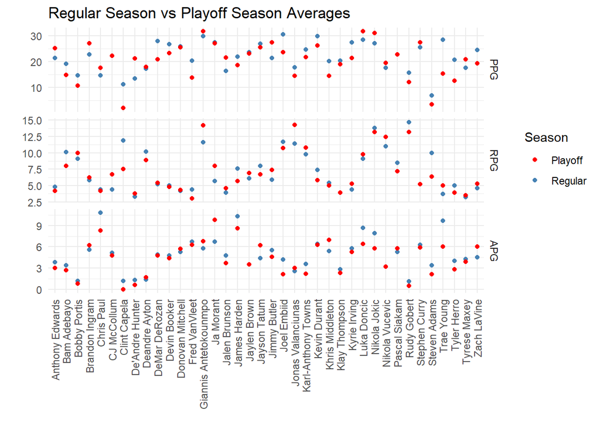

```r
# plot facet-wrapped graph
ggplot(nba_pivot, aes(Player, regular, color = "Regular")) +
  geom_point() +
  geom_point(aes(Player, playoffs, color = "Playoff")) +
  facet_grid(Stat ~ ., scales = "free_y") +
  scale_color_manual(name = "Season", values = c("Regular" = "steelblue", "Playoff" = "red")) +
  labs(title = "Regular Season vs Playoff Season Averages") +
  labs(x = "", y ="") +
  theme_minimal() +
  theme(axis.text.x = element_text(angle = 90, vjust = 0.5, hjust = 1))
```

### Narrative

Despite the few outliers most players performed close to their regular season averages in the playoffs. Although most of the averages went down from the regular season to the playoffs. This could contribute to the fact that the level of play increases in the playoffs, especially defensively, as the playoffs are what truly matters when it comes to winning. If the NBA wants all players to play at their peak level throughout the season and not just the playoffs then they might want to think about reducing the amount of games during the regular season. This graph is mainly directed towards NBA analysts and NBA coaches. A lot of analysts discuss who will show up in the playoffs and if they will fail to perform under the pressure. These graphs could provide good insight on who might over perform or under perform when it comes to the playoffs. This graph may also provide good information to coaches when considering who to trade for or sign later in the season if they want a better chance at winning the NBA finals.